# Homework 6

Luis Barraza-Tirado

2026-01-26

## Instructions

Answer the following questions and/or complete the exercises in RMarkdown. Please embed all of your code and push the final work to your repository. Your report should be organized, clean, and run free from errors. Remember, you must remove the `#` for any included code chunks to run.

## Load the tidyverse

```r
library("tidyverse")
library("janitor")
```

## Data

For this assignment, we will use data from a study on vertebrate community composition and impacts from defaunation in [Gabon, Africa](https://en.wikipedia.org/wiki/Gabon). One thing to notice is that the data include 24 separate transects. Each transect represents a path through different forest management areas.

Reference: Koerner SE, Poulsen JR, Blanchard EJ, Okouyi J, Clark CJ. Vertebrate community composition and diversity declines along a defaunation gradient radiating from rural villages in Gabon. *Journal of Applied Ecology*. 2016. A description of the variables is included inside the data folder.

**1. Load `IvindoData_DryadVersion.csv` and store it as a new object called `gabon`.**

```r
gabon <- read.csv("data/IvindoData_DryadVersion.csv") %>% clean_names()
```

**2. Use one or more of the summary functions you have learned to get an idea of the structure of the data.**

```r
glimpse(gabon)
```

```
## Rows: 24
## Columns: 26
## $ transect_id              <int> 1, 2, 2, 3, 4, 5, 6, 7, 8, 9, 13, 14, 15, 16,…
## $ distance                 <dbl> 7.14, 17.31, 18.32, 20.85, 15.95, 17.47, 24.0…
## $ hunt_cat                 <chr> "Moderate", "None", "None", "None", "None", "…
## $ num_households           <int> 54, 54, 29, 29, 29, 29, 29, 54, 25, 73, 46, 5…
## $ land_use                 <chr> "Park", "Park", "Park", "Logging", "Park", "P…
## $ veg_rich                 <dbl> 16.67, 15.75, 16.88, 12.44, 17.13, 16.50, 14.…
## $ veg_stems                <dbl> 31.20, 37.44, 32.33, 29.39, 36.00, 29.22, 31.…
## $ veg_liana                <dbl> 5.78, 13.25, 4.75, 9.78, 13.25, 12.88, 8.38, …
## $ veg_dbh                  <dbl> 49.57, 34.59, 42.82, 36.62, 41.52, 44.07, 51.…
## $ veg_canopy               <dbl> 3.78, 3.75, 3.43, 3.75, 3.88, 2.50, 4.00, 4.0…
## $ veg_understory           <dbl> 2.89, 3.88, 3.00, 2.75, 3.25, 3.00, 2.38, 2.7…
## $ ra_apes                  <dbl> 1.87, 0.00, 4.49, 12.93, 0.00, 2.48, 3.78, 6.…
## $ ra_birds                 <dbl> 52.66, 52.17, 37.44, 59.29, 52.62, 38.64, 42.…
## $ ra_elephant              <dbl> 0.00, 0.86, 1.33, 0.56, 1.00, 0.00, 1.11, 0.4…
## $ ra_monkeys               <dbl> 38.59, 28.53, 41.82, 19.85, 41.34, 43.29, 46.…
## $ ra_rodent                <dbl> 4.22, 6.04, 1.06, 3.66, 2.52, 1.83, 3.10, 1.2…
## $ ra_ungulate              <dbl> 2.66, 12.41, 13.86, 3.71, 2.53, 13.75, 3.10, …
## $ rich_all_species         <int> 22, 20, 22, 19, 20, 22, 23, 19, 19, 19, 21, 2…
## $ evenness_all_species     <dbl> 0.793, 0.773, 0.740, 0.681, 0.811, 0.786, 0.8…
## $ diversity_all_species    <dbl> 2.452, 2.314, 2.288, 2.006, 2.431, 2.429, 2.5…
## $ rich_bird_species        <int> 11, 10, 11, 8, 8, 10, 11, 11, 11, 9, 11, 11, …
## $ evenness_bird_species    <dbl> 0.732, 0.704, 0.688, 0.559, 0.799, 0.771, 0.8…
## $ diversity_bird_species   <dbl> 1.756, 1.620, 1.649, 1.162, 1.660, 1.775, 1.9…
## $ rich_mammal_species      <int> 11, 10, 11, 11, 12, 12, 12, 8, 8, 10, 10, 11,…
## $ evenness_mammal_species  <dbl> 0.736, 0.705, 0.650, 0.619, 0.736, 0.694, 0.7…
## $ diversity_mammal_species <dbl> 1.764, 1.624, 1.558, 1.484, 1.829, 1.725, 1.9…
```

**3. Clean the data as necessary following the conventions from lab 6.**

```r
gabon <- gabon %>%
  mutate(across(where(is.character), tolower))
```

```r
glimpse(gabon)
```

```
## Rows: 24
## Columns: 26
## $ transect_id              <int> 1, 2, 2, 3, 4, 5, 6, 7, 8, 9, 13, 14, 15, 16,…
## $ distance                 <dbl> 7.14, 17.31, 18.32, 20.85, 15.95, 17.47, 24.0…
## $ hunt_cat                 <chr> "moderate", "none", "none", "none", "none", "…
## $ num_households           <int> 54, 54, 29, 29, 29, 29, 29, 54, 25, 73, 46, 5…
## $ land_use                 <chr> "park", "park", "park", "logging", "park", "p…
## $ veg_rich                 <dbl> 16.67, 15.75, 16.88, 12.44, 17.13, 16.50, 14.…
## $ veg_stems                <dbl> 31.20, 37.44, 32.33, 29.39, 36.00, 29.22, 31.…
## $ veg_liana                <dbl> 5.78, 13.25, 4.75, 9.78, 13.25, 12.88, 8.38, …
## $ veg_dbh                  <dbl> 49.57, 34.59, 42.82, 36.62, 41.52, 44.07, 51.…
## $ veg_canopy               <dbl> 3.78, 3.75, 3.43, 3.75, 3.88, 2.50, 4.00, 4.0…
## $ veg_understory           <dbl> 2.89, 3.88, 3.00, 2.75, 3.25, 3.00, 2.38, 2.7…
## $ ra_apes                  <dbl> 1.87, 0.00, 4.49, 12.93, 0.00, 2.48, 3.78, 6.…
## $ ra_birds                 <dbl> 52.66, 52.17, 37.44, 59.29, 52.62, 38.64, 42.…
## $ ra_elephant              <dbl> 0.00, 0.86, 1.33, 0.56, 1.00, 0.00, 1.11, 0.4…
## $ ra_monkeys               <dbl> 38.59, 28.53, 41.82, 19.85, 41.34, 43.29, 46.…
## $ ra_rodent                <dbl> 4.22, 6.04, 1.06, 3.66, 2.52, 1.83, 3.10, 1.2…
## $ ra_ungulate              <dbl> 2.66, 12.41, 13.86, 3.71, 2.53, 13.75, 3.10, …
## $ rich_all_species         <int> 22, 20, 22, 19, 20, 22, 23, 19, 19, 19, 21, 2…
## $ evenness_all_species     <dbl> 0.793, 0.773, 0.740, 0.681, 0.811, 0.786, 0.8…
## $ diversity_all_species    <dbl> 2.452, 2.314, 2.288, 2.006, 2.431, 2.429, 2.5…
## $ rich_bird_species        <int> 11, 10, 11, 8, 8, 10, 11, 11, 11, 9, 11, 11, …
## $ evenness_bird_species    <dbl> 0.732, 0.704, 0.688, 0.559, 0.799, 0.771, 0.8…
## $ diversity_bird_species   <dbl> 1.756, 1.620, 1.649, 1.162, 1.660, 1.775, 1.9…
## $ rich_mammal_species      <int> 11, 10, 11, 11, 12, 12, 12, 8, 8, 10, 10, 11,…
## $ evenness_mammal_species  <dbl> 0.736, 0.705, 0.650, 0.619, 0.736, 0.694, 0.7…
## $ diversity_mammal_species <dbl> 1.764, 1.624, 1.558, 1.484, 1.829, 1.725, 1.9…
```

**4. Use `mutate()` Change the variables `HuntCat`, `LandUse`, and `TransectID` to factors. Be sure to store the output as a new dataframe and use it for the remaining questions.**

```r
gabon%>%
  mutate(across(c("hunt_cat", "land_use", "transect_id"), as.factor))
```

```
##    transect_id distance hunt_cat num_households land_use veg_rich veg_stems
## 1            1     7.14 moderate             54     park    16.67     31.20
## 2            2    17.31     none             54     park    15.75     37.44
## 3            2    18.32     none             29     park    16.88     32.33
## 4            3    20.85     none             29  logging    12.44     29.39
## 5            4    15.95     none             29     park    17.13     36.00
## 6            5    17.47     none             29     park    16.50     29.22
## 7            6    24.06     none             29     park    14.75     31.22
## 8            7    19.81     none             54  logging    13.25     32.56
## 9            8     5.78     high             25  neither    12.63     23.67
## 10           9     5.13     high             73  logging    16.00     27.11
## 11          13     6.61 moderate             46  logging    12.38     23.44
## 12          14     8.23 moderate             56  logging    15.75     30.22
## 13          15     2.70     high             46  neither    10.88     25.44
## 14          16     6.10 moderate             36  logging    14.63     39.11
```

[output cut: 135 more lines]

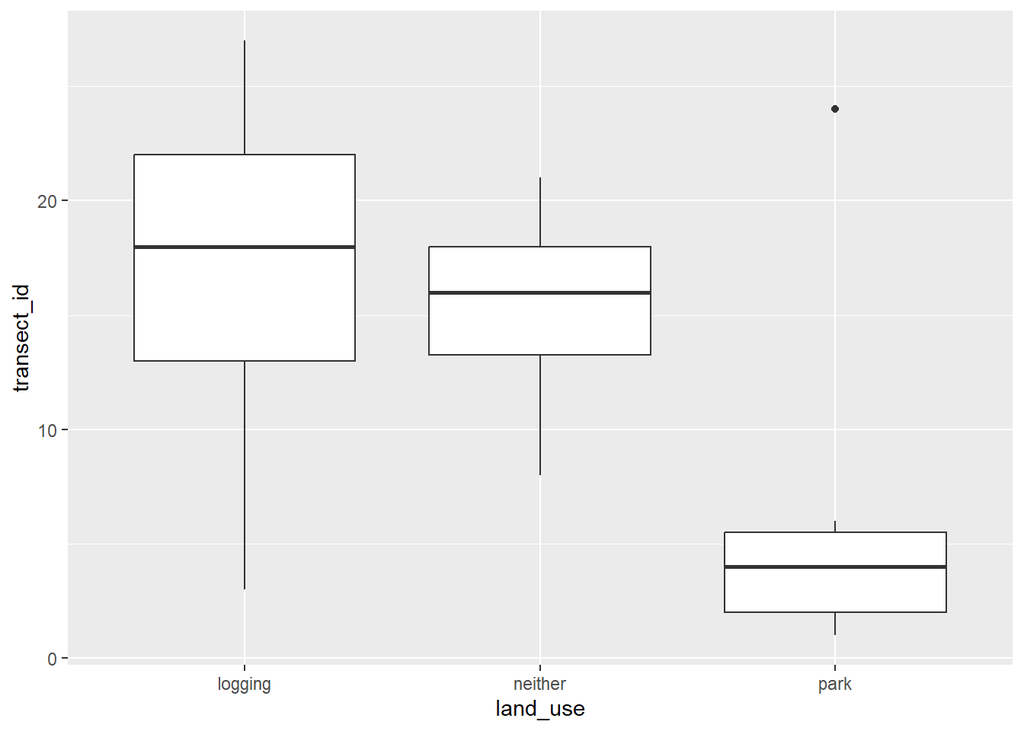

```r
ggplot(gabon,
       mapping = aes(y= transect_id, x= land_use))+
  geom_boxplot()
```

**6. How does vegetation richness compare among land use types?**

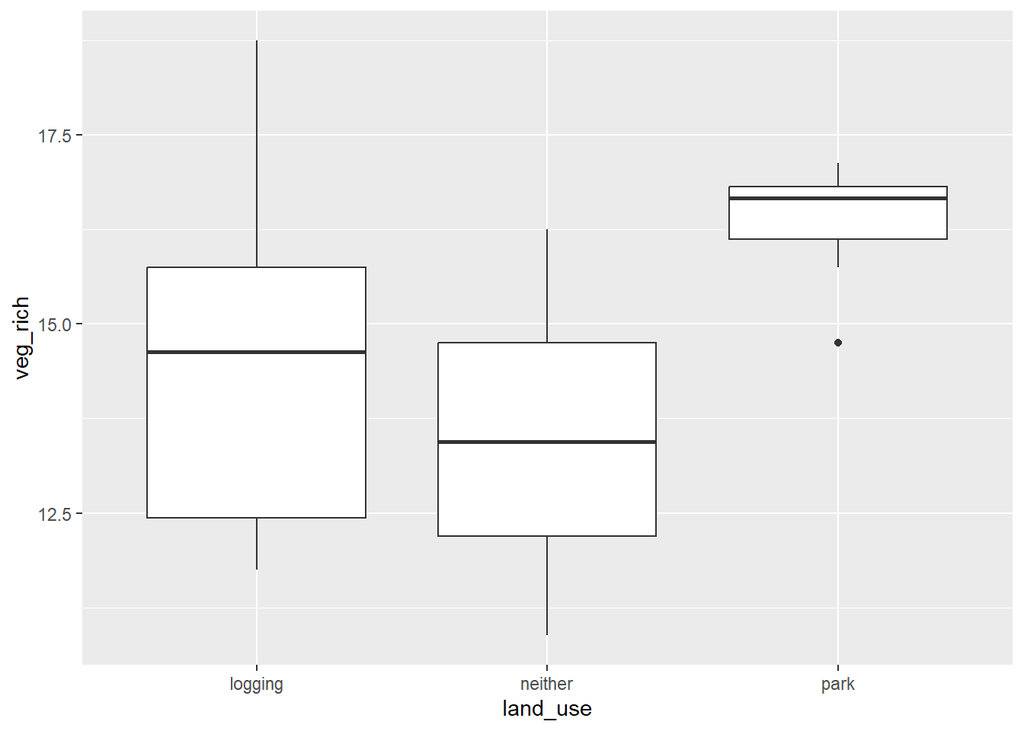

```r
ggplot(gabon,
       mapping = aes(x=land_use, y=veg_rich))+
  geom_boxplot()
```

**7. For which land use type (national parks, logging, or neither) is average all species diversity the greatest?**

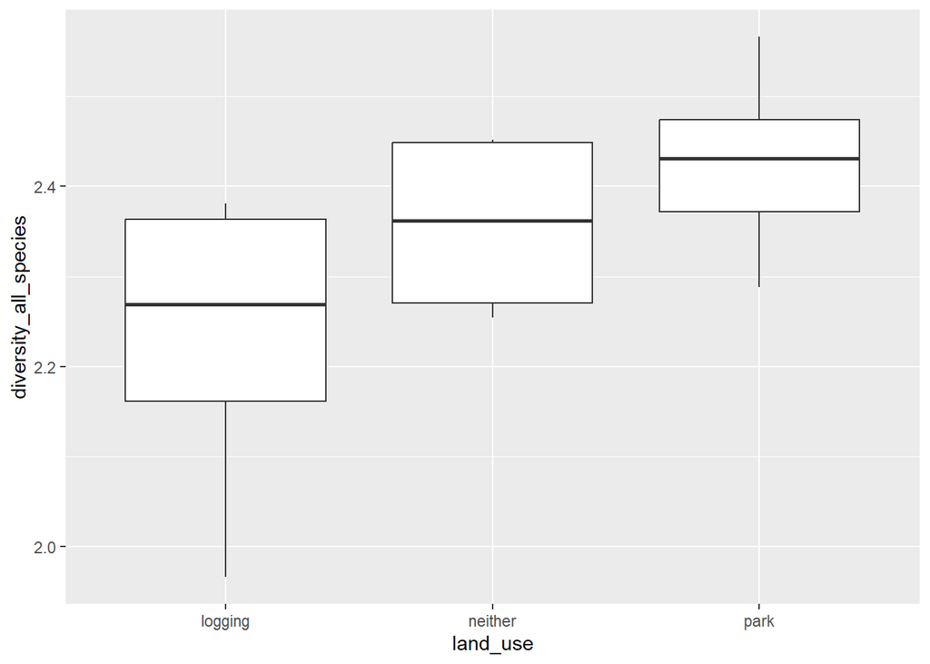

```r
ggplot(gabon,
       mapping = aes(x=land_use, y=diversity_all_species))+
  geom_boxplot()
```

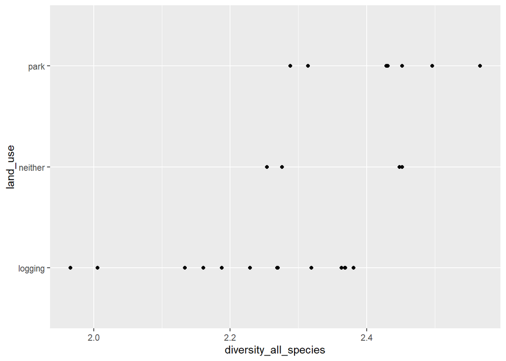

```r
ggplot(gabon,
       mapping = aes(y=land_use, x=diversity_all_species))+
  geom_point()
```

**8. Is there a relationship between vegetation richness and mammal species richness?**

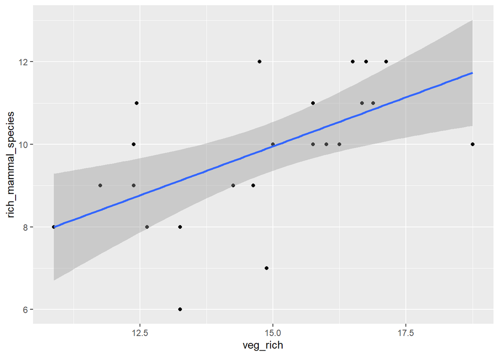

```r
ggplot(gabon,
       mapping = aes(y= rich_mammal_species, x= veg_rich))+
  geom_point()+
  geom_smooth(method = lm, se= T)
```

**9. Use `filter` to find all transects that have greater than 15 tree species or a breast height diameter between 50 and 60cm.**

```r
names(gabon)
```

```
##  [1] "transect_id"              "distance"
##  [3] "hunt_cat"                 "num_households"
##  [5] "land_use"                 "veg_rich"
##  [7] "veg_stems"                "veg_liana"
##  [9] "veg_dbh"                  "veg_canopy"
## [11] "veg_understory"           "ra_apes"
## [13] "ra_birds"                 "ra_elephant"
## [15] "ra_monkeys"               "ra_rodent"
## [17] "ra_ungulate"              "rich_all_species"
## [19] "evenness_all_species"     "diversity_all_species"
## [21] "rich_bird_species"        "evenness_bird_species"
## [23] "diversity_bird_species"   "rich_mammal_species"
## [25] "evenness_mammal_species"  "diversity_mammal_species"
```

```r
gabon %>%
  select(transect_id, veg_dbh)%>%
  filter(transect_id>=15, between(veg_dbh, 50,60))
```

```
##   transect_id veg_dbh
## 1          15   54.77
## 2          17   57.71
## 3          21   50.36
```

**10.Which transects and land use types have more than 10 tree species and 10 mammal species? Use `arrange()` to sort by the number of tree species.**

```r
gabon %>%
  select(transect_id, land_use, veg_liana, rich_mammal_species) %>%
  filter(veg_liana>=10, rich_mammal_species>=10)
```

```
##   transect_id land_use veg_liana rich_mammal_species
## 1           2     park     13.25                  10
## 2           4     park     13.25                  12
## 3           5     park     12.88                  12
## 4          14  logging     14.13                  11
## 5          21  neither     15.38                  10
## 6          22  logging     13.38                  12
## 7          24     park     10.00                  12
## 8          25  logging     12.60                  10
## 9          26  logging     16.00                  10
```

## Knit and Upload

Please knit your work as an .html file and upload to Canvas. Homework is due before the start of the next lab. No late work is accepted. Make sure to use the formatting conventions of RMarkdown to make your report neat and clean!